# Projekt 2: Zarobki w branży analizy danych na podstawie ogłoszeń pracy Stanach Zjednoczonych

Sebastian Sukiennik

1/11/2022

## Wprowadzanie

W wybranym zbiorze danych znajdują się informacje na temat ofert pracy w branży analizy danych. Zebrane dane przedstawiają 40 atrybutów ogłoszeń pulibkowanych na rynku pracy Stanów Zjednoczonych. Niektóre z występujących kolumn:

- Job.Title - tytuł ogłoszenia
- Salary.Estimate - estymacja wynagrodzenia według portalu Glassdoor (tworzy estymacje na podstawie anonimowych opini byłych i aktualnych pracowników)
- Rating - ocena stanowiska pracy wdg. Glassdoor
- Age - liczba dni od dodania ogłoszenia
- Python, Spark, aws… - kolumny nazw technologi wymaganych na stanowisko (0/1 - nie wymagana/wymagana)
- job_title_sim - kategoria rodzaju pracy
- seniority_by_title - tytuł poziomu doświadzczenia
- Degree - minimalny wymagany poziom wykształcenie

W niektórych komórkach występują wartości -1 lub “na” według autora zbioru danych oznaczają one wartości których nie udało się zebrać dla danego ogłoszenia.

> Głównym celem mojego projektu jest wyznaczenie atrybutów charakterystycznyhch dla najlepiej opłacanych stanowisk pracy w branży. Jaki poziom wykształcenia, doświadczenia, poznane technologie zapewnią przyszłemu analitykowi danych najwyżse zarobki. Postaram się także odpowiedzieć czy wynagrodzenie zależy od lokalizacji, wielkości, ratingu (itp.) firmy, a jeśli tak, to gdzie należy szukać stanowisk z najwyższymi stawkami.

Usuwam kolumny Job.Description oraz Competitors, ponieważ w mojej analizie nie zamierzam korzystać z informacji zawaratych w tych kolumnach.

```r
data_withoutdesc <- data %>%
  select(-c(Job.Description, Competitors))
head(data_withoutdesc)
```

```
##   index                 Job.Title             Salary.Estimate Rating
## 1     0            Data Scientist  $53K-$91K (Glassdoor est.)    3.8
## 2     1 Healthcare Data Scientist $63K-$112K (Glassdoor est.)    3.4
## 3     2            Data Scientist  $80K-$90K (Glassdoor est.)    4.8
## 4     3            Data Scientist  $56K-$97K (Glassdoor est.)    3.8
## 5     4            Data Scientist $86K-$143K (Glassdoor est.)    2.9
## 6     5            Data Scientist $71K-$119K (Glassdoor est.)    3.4
##                                 Company.Name        Location   Headquarters
## 1                     Tecolote Research\n3.8 Albuquerque, NM     Goleta, CA
## 2 University of Maryland Medical System\n3.4   Linthicum, MD  Baltimore, MD
## 3                               KnowBe4\n4.8  Clearwater, FL Clearwater, FL
## 4                                  PNNL\n3.8    Richland, WA   Richland, WA
## 5                    Affinity Solutions\n2.9    New York, NY   New York, NY
## 6                              CyrusOne\n3.4      Dallas, TX     Dallas, TX
##           Size Founded  Type.of.ownership                         Industry
```

[output cut: 41 more lines]

Aby lepiej poznać dane wypisuję unikalne wartości z kolumn zawierających dane kategoryczne, oraz statystki opisowe dla kolumn z danymi numerycznymi. Przy wypisywaniu unikalnych wartości odrzuciłem kolumny typu: Job.Title, Company.Name, ponieważ dla większości ogłoszeń były to wartości niepowtarzalne, wypisanie np. 500 nazw firm bylo zwyczajnie nieczytalne i nie wnosiło żadnych istotnych informacji.

```r
(data_withoutdesc %>%
  select(where(is.character)) %>%
  select(-c(Job.Title, Salary.Estimate, Company.Name, Headquarters, company_txt, Location)) %>%
  lapply(unique))
```

```
## $Size
## [1] "501 - 1000 "   "10000+ "       "1001 - 5000 "  "51 - 200 "
## [5] "201 - 500 "    "5001 - 10000 " "1 - 50 "       "unknown"
##
## $Type.of.ownership
## [1] "Company - Private"              "Other Organization"
## [3] "Government"                     "Company - Public"
## [5] "Hospital"                       "Subsidiary or Business Segment"
## [7] "Nonprofit Organization"         "College / University"
## [9] "School / School District"
##
## $Industry
##  [1] "Aerospace & Defense"
##  [2] "Health Care Services & Hospitals"
##  [3] "Security Services"
```

[output cut: 99 more lines]

Przy badaniu dancyh numerycznych pominąłem kolumny w których zawarte były dane w zasadzie kategoryczne (np. kolumny z technologiami mają dane 0/1).

```r
(data_withoutdesc %>%
   select(c(Rating, Hourly, Lower.Salary, Upper.Salary, Avg.Salary.K., Age)) %>%
   summarise(across(where(is.numeric), ~ list(summary(.)))))
```

```
##                                                        Rating
## 1 -1.000000, 3.300000, 3.700000, 3.618868, 4.000000, 5.000000
##                                                                   Hourly
## 1 0.00000000, 0.00000000, 0.00000000, 0.03234501, 0.00000000, 1.00000000
##                                                  Lower.Salary
## 1 15.00000, 52.00000, 69.50000, 74.75472, 91.00000, 202.00000
##                                               Upper.Salary
## 1 16.0000, 96.0000, 124.0000, 128.2143, 155.0000, 306.0000
##                                             Avg.Salary.K.
## 1 15.5000, 73.5000, 97.5000, 101.4845, 122.5000, 254.0000
##                                                           Age
## 1 -1.00000, 12.00000, 25.00000, 47.52426, 60.00000, 277.00000
```

## Pytanie 1

> Czy średnia zarboków zależy od wymaganego minimalnego wykształcenia

```r
count <- data_withoutdesc %>%
  count(Degree)

data <- data_withoutdesc %>%
  select(c(Degree, Avg.Salary.K.)) %>%
  group_by(Degree) %>%
  summarize(Mean = mean(Avg.Salary.K.), Median = median(Avg.Salary.K.))

data$Count = count$n
data
```

```
## # A tibble: 3 × 4
##   Degree  Mean Median Count
##   <chr>  <dbl>  <dbl> <int>
## 1 M      106.    102.   252
## 2 na      94.7    89    383
## 3 P      116.    120    107
```

Aż 383 ogłoszenia mają w kolumnie Degree wpisane wartości “na”. Ponieważ średnie wynagrodzenie i mediana dla tych ogłoszeń są niższe od ogłoszeń z wymaganym wykształceniem Masters/Phd to uważam że wartości “na” w większości odpowiadają minimalnemu wykształceniu wymaganemu na tego typu stanowiskach (Bachelors Degree). Istnieje oczywiście możliwość że w niektórych ogłoszeniach zwyczajnie nie ma określonego minimalnego wykształcenia, jednakże znając realia obecnego rynku pracy zostanę przy założeniu że chodzi o Bachelors Degree.

```r
data_withoutdesc <- data_withoutdesc %>%
  mutate(Degree = case_when(Degree == "na" ~ "B",
                            TRUE ~ Degree))
data_withoutdesc$Degree <- factor(data_withoutdesc$Degree, levels = c('B', 'M', 'P'))

plot1 <- ggplot(data = data_withoutdesc, aes(x=Degree, y = Avg.Salary.K.)) +
  geom_boxplot(aes(fill=Degree))  +
  labs(title = "Srednia zarobków według wykształcenia", y = "Średnie wynagrodzenie", x = "Poziom wykształcenia") +
  theme_minimal() +
  theme(plot.title = element_text(hjust = 0.5))
```

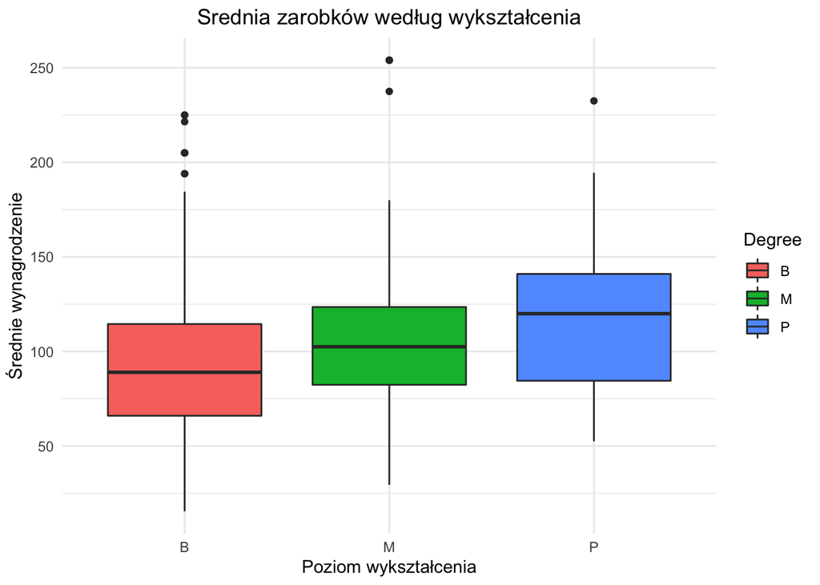

## Pytanie 2

> Jakie technologie są wymagane w najlepiej opłacanych ofertach pracy

Wezmę 20 najwyżej opłacanych ogłoszeń pracy dla każdego poziomu wykształcenia i przedstawię jakie technologie są w nich najczęściej wymagane

```r
data <- data_withoutdesc %>%
  select(Degree, Avg.Salary.K., Python, spark, aws, excel, sql, sas, keras, pytorch, scikit, tensor, hadoop, tableau, bi, flink, mongo, google_an) %>%
  arrange(desc(Avg.Salary.K.)) %>%
  group_by(Degree)
```

Funkcje do usuwania wartości odstających, sumowania liczby wystąpień technologi w ogłoszeniach oraz do tworzenia wykresów kolumnowych.

```r
remove_outliers <- function(data){
  Q <- quantile(data$Avg.Salary.K., probs=c(.25, .75), na.rm = FALSE)
  iqr <- IQR(data$Avg.Salary.K.)
  up <-  Q[2]+1.5*iqr # Upper Range
  low<- Q[1]-1.5*iqr # Lower Range
  eliminated <- subset(data, data$Avg.Salary.K. > (Q[1] - 1.5*iqr) & data$Avg.Salary.K. < (Q[2]+1.5*iqr))
  eliminated
}

calculate_tech <- function(data){
  data <- data %>%
    gather("tech", "n") %>%
    filter(tech != "Degree" & tech != "Avg.Salary.K.") %>%
    group_by(tech) %>%
    summarise(sum = sum(as.numeric(n))) %>%
    arrange(desc(sum))
  data
}

plot_tech <- function(data){
  plot2 <- ggplot(data, aes(x = tech, y = sum)) +
  geom_bar(stat="identity", fill="steelblue")
  plot2
}
```

```r
data_b <- data %>%
  filter(Degree == "B")
data_m <- data %>%
  filter(Degree == "M")
data_p <- data %>%
  filter(Degree == "P")

data_b <- remove_outliers(data_b) %>% slice(0:20)
data_m <- remove_outliers(data_m) %>% slice(0:20)
data_p <- remove_outliers(data_p) %>% slice(0:20)

db <- calculate_tech(data_b)
dm <- calculate_tech(data_m)
dp <- calculate_tech(data_p)
all <- bind_rows(list("B"=db, "M"=dm, "P"=dp), .id = "groups")
all <- all %>%
  filter(!(tech %in% c("bi", "google_an", "keras", "pytorch")))
```

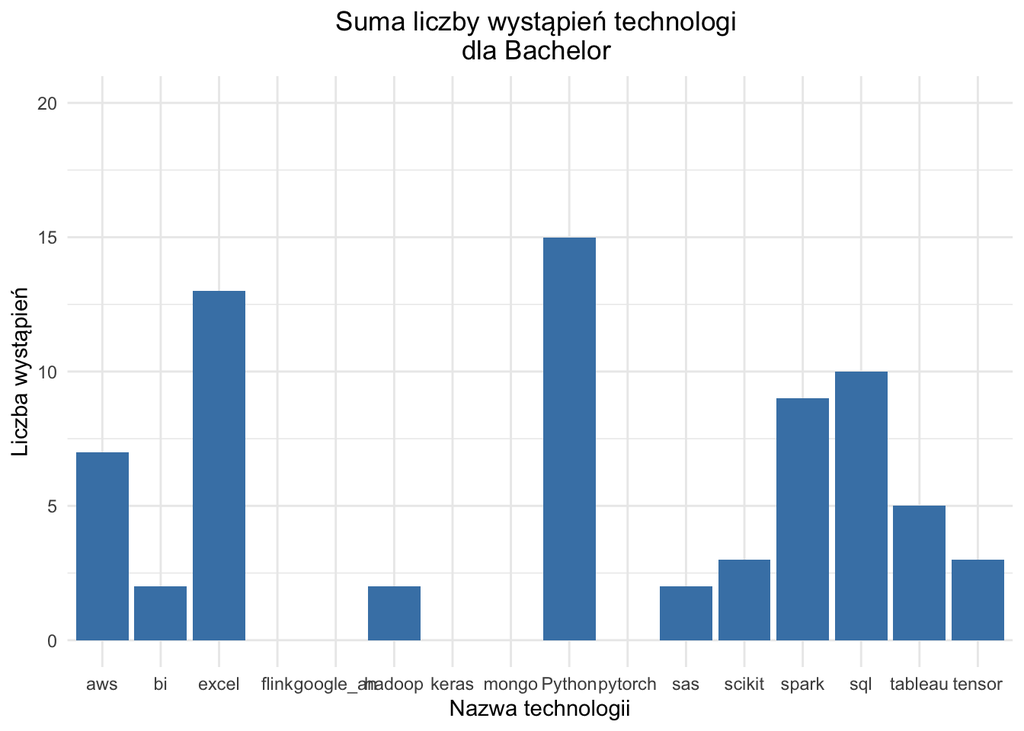

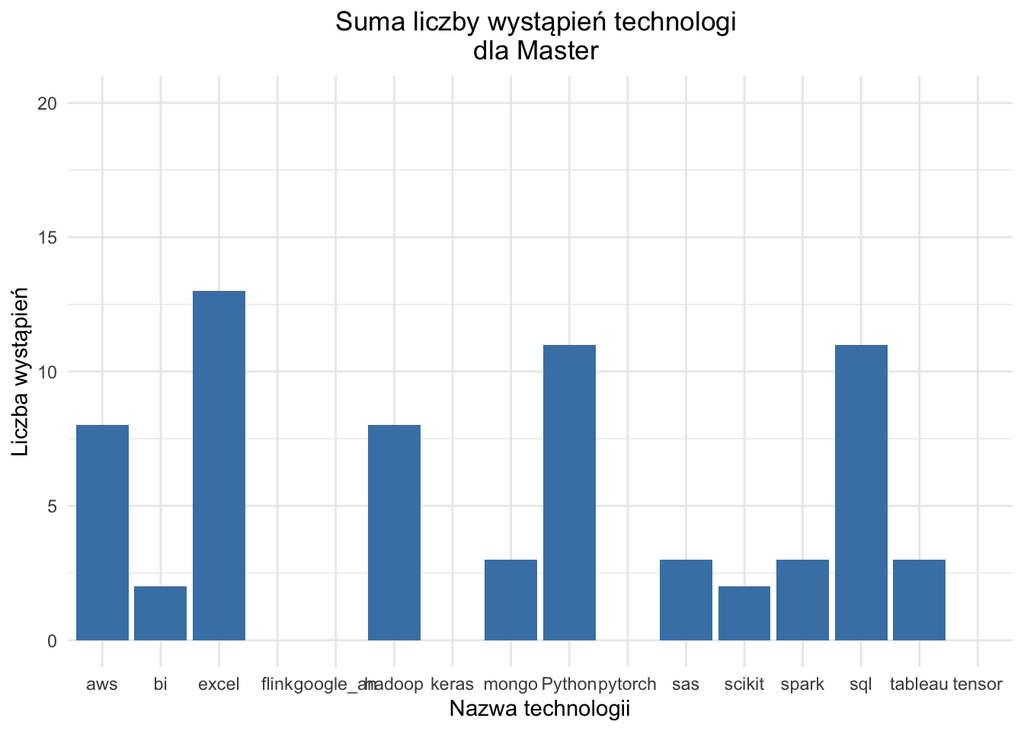

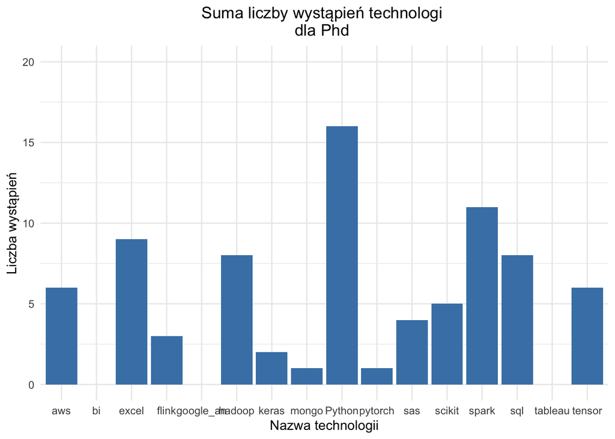

## Pytanie 3

> Czy wynagrodzenie zależy od liczby lat istnienia firmy

Odsiewam niepotrzebne dane, groupuję według roku założenia firmy i dla każdego roku obliczam średnie wynagrodzenie. Na koniec sortuję rosnąco według roku założenia i tworzę wykres liniowy z otrzymanymi wynikami.

```r
data <- data_withoutdesc %>%
  select(Founded, Avg.Salary.K., Degree) %>%
  filter(Founded > 1900) %>%
  group_by(Founded, Degree) %>%
  summarise(Mean = mean(Avg.Salary.K.)) %>%
  arrange(Founded)
```

```r
plotb <- ggplot(data%>%filter(Degree=="B"), aes(x=Founded, y = Mean, color=Degree)) +
  geom_line() +
  ylim(0, 200) +
  theme_minimal()
plotm <- ggplot(data%>%filter(Degree=="M"), aes(x=Founded, y = Mean, color=Degree)) +
  geom_line() +
  ylim(0, 200) +
  theme_minimal()
plotp <- ggplot(data%>%filter(Degree=="P"), aes(x=Founded, y = Mean, color=Degree)) +
  geom_line() +
  ylim(0, 200) +
  theme_minimal()
```

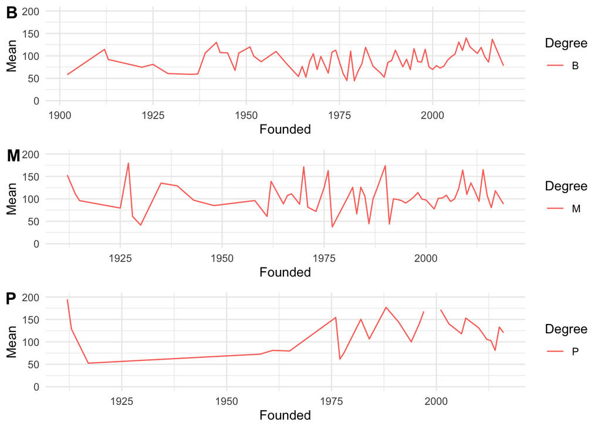

## Pytanie 4

> Jak wielkości firmy wpływa na średnie zarobki

```r
data_withoutdesc <- data_withoutdesc %>%
  filter(Size != "unknown")


data_withoutdesc$Size <- factor(data_withoutdesc$Size, levels = c('1 - 50 ', '51 - 200 ', '201 - 500 ', '501 - 1000 ', '1001 - 5000 ', '5001 - 10000 ', '10000+ '))
data <- data_withoutdesc %>%
  select(Size, Avg.Salary.K., Degree) %>%
  group_by(Size, Degree) %>%
  summarise(Mean = mean(Avg.Salary.K.))
```

```r
plot2 <- ggplot(data, aes(x = Size, y = Mean, fill=Degree))+
  geom_bar(stat="identity", position=position_dodge()) +
  ylim(0, 200) +
  labs(title = "Średnia zarobków według wielkości firmy \ni stopnia wykształcenia") +
  theme_minimal() +
  theme(plot.title = element_text(hjust = 0.5))
```

Na opniższym wykresie widać że w małych (do 500 osób) i dużych (10000+ osób) firmach pracownicy z Phd mają zarobki podobne lub nawet niższe od tych z wykształceniem na poziomie Masters. Natomiast zarobki osób z wykształceniem Bachelor degree są zdecydowanie niższe od lepiej wykształconych współpracowników tylko w firmach do 50 osób i w największych korporacjach. W pozostałych przypadkach zarbaiją tylko minimalnie mniej od Masters’ów. Podsumowując:

- Bachelor degree powininen szukać zatrudnienia w małych firmach do 500 osób
- Mastersi powinni skupić się na firmach do 200 osób lub korporacjach powyżej 10 000 pracowników gdzie zarobi prawie tyle samo co Phd
- Phd otrzyma najlepsze wynagrodzenie w firmach wielkość 501-1000 osób lub powyżej 5000 zatrudnionych osób

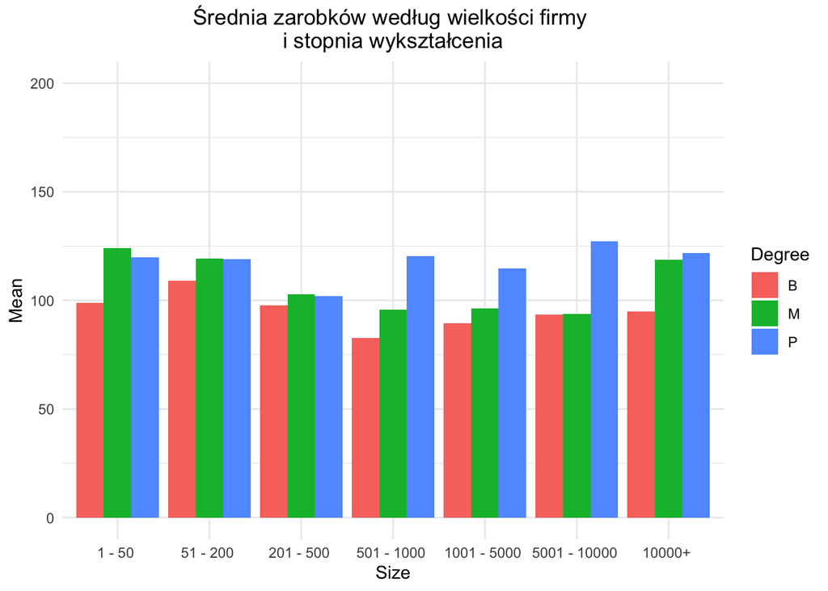

## Pytanie 5

> Czy średnie zarobki zależą od ratingu firmy

Na początek wybieram interesujące mnie dane, odsiewam obserwacje z ujemnymi wynikami ratingu (nie udało się zebrać danych dla danego ogłoszenia). Dodaję także kolumnę lt150 która przyjmuje wartości bool (TRUE dla wierszy gdzie Avg.Salary.K. nie przekracza 150 tys. $). Tworząc wykres punktowy przy użyciu geom_point() koloruję punkty odowiadające ogłoszeniom firm w których średnie zarobki przekraczają 150 tys dolarów. Ponieważ ratingi są określane z dokładnośćią do jednego miejsca po przecinku, na wykresie widać wyraźne pionowe linie skupienia punktów. Aby lepiej zwizulizować natężenie obserwacji w danym miejscu wykresu używam argumentu *alpha=0.6*.  
Można zauważyć, że większość firm zawiera się w przedziale od 2 do 5 i tylko jedna z ponad 700 firm uzyskała rating poniżej 2 punktów.

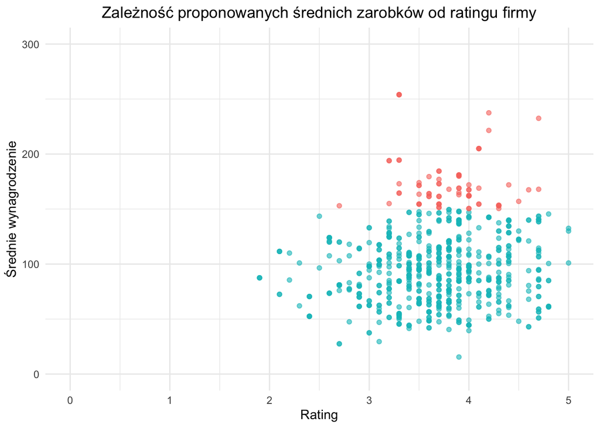

```r
data <- data_withoutdesc %>%
  select(Rating, Avg.Salary.K., Degree) %>%
  filter(Rating > 0) %>%
  mutate(lt150 = Avg.Salary.K.<=150)

plot3 <- ggplot(data , aes(x = Rating, y = Avg.Salary.K.)) +
          geom_point(stat="identity", aes(color=lt150), alpha = 0.6) +
          xlim(0, 5) +
          ylim(0, 300) +
          labs(title= "Zależność proponowanych średnich zarobków od ratingu firmy", y="Średnie wynagrodzenie") +
          theme_minimal() +
          theme(plot.title = element_text(hjust = 0.5), legend.position = "none")
```

Z wykresu można wywnioskować, że większość firm oferujących stanowiska z wynagrodzeniem powyżej 150 000 dolarów ma wysokośc ratingu zawierającą się w przedziale 3 do 4.5. Aby sprawdzić jaki procent interesujących mnie firm faktycznie zawiera się w tym przedziale, obliczam sumę wszystkich firm z wyngrodzeniem powyżej 150 tysięcy, następnie obliczam ile z nich ma rating większy od 3 i mniejszy od 4,5 a na koniec liczę stosunek tych wartości.

```r
gt150 <- sum(!data$lt150)
gt150_inrange <- data %>%
  select(Avg.Salary.K., lt150, Rating) %>%
  filter(Rating >= 3 & Rating <= 4.5 & !lt150)
gt150_inrange_sum <- length(gt150_inrange$Rating)

(round(gt150_inrange_sum/gt150, 2))
```

```
## [1] 0.95
```

Jak się okazuje aż 95% firm oferujących wynagrodzenie większe bądź równe 150 tys. $ ma rating z przedziału [3; 4.5]. A więc wbrew pozorom firmy z największymi wynagrodzeniami nie osiągają najwyższych ocen. Na wykresie widzimy kilka ogłoszeń firm z najwyższą możliwą oceną (5) a oferujących płace na poziomie nie przekraczającym 150 tysięcy dolarów.

## Pytanie 6

> Jak kształtuje się średnia płaca względem tytułu stanowiska

W celu odpowiedzi na to pytanie, rozpoczynam od interesujących mnie kolumn, odsiania brakujących wartości z kolumny job_title_sim a następnie skróceniu dłuższych wartości zmiennych. Zliczam liczbę ogłoszeń pogrupowanych wedlug poszukiwanego stanowiska. Dzięki temu mogę zauważyć, że data analitics występuje tylko w 8 ogłoszeniach a data modeler i director w zaledwiu 5. Zdecydowałem odrzucić obserwacje zawierające te 3 stanowsika, ponieważ ze względu na małą liczbę obserwacji, wykres dla nich mógłby przedstawiać wartości fałszywie zawyżone/zaniżone.

```r
data <- data_withoutdesc %>%
  select(job_title_sim, Avg.Salary.K.) %>%
  filter(job_title_sim != "na") %>%
  mutate(job_title_sim = case_when(job_title_sim == "machine learning engineer" ~ "ML engineer",
                   job_title_sim == "Data scientist project manager" ~ "Data scientist PM",
                   TRUE ~ job_title_sim))

(count_by_jtitle <- data %>%
  group_by(job_title_sim) %>%
  count() %>%
  arrange(desc(n)))
```

```
## # A tibble: 9 × 2
## # Groups:   job_title_sim [9]
##   job_title_sim         n
##   <chr>             <int>
## 1 data scientist      310
## 2 other scientist     136
## 3 data engineer       119
## 4 analyst             101
## 5 ML engineer          22
## 6 Data scientist PM    16
## 7 data analitics        8
## 8 data modeler          5
## 9 director              5
```

```r
top_count_title <- count_by_jtitle %>%
  head(6) %>%
  select(job_title_sim)
```

Ponownie filtruję dane, tym razem odrzucają obserwacje dla 3 ww. stanowisk. Otrzymane dane przedstawiam na wykresie pudełkowym podzielonym według tytułu stanowiska pracy.

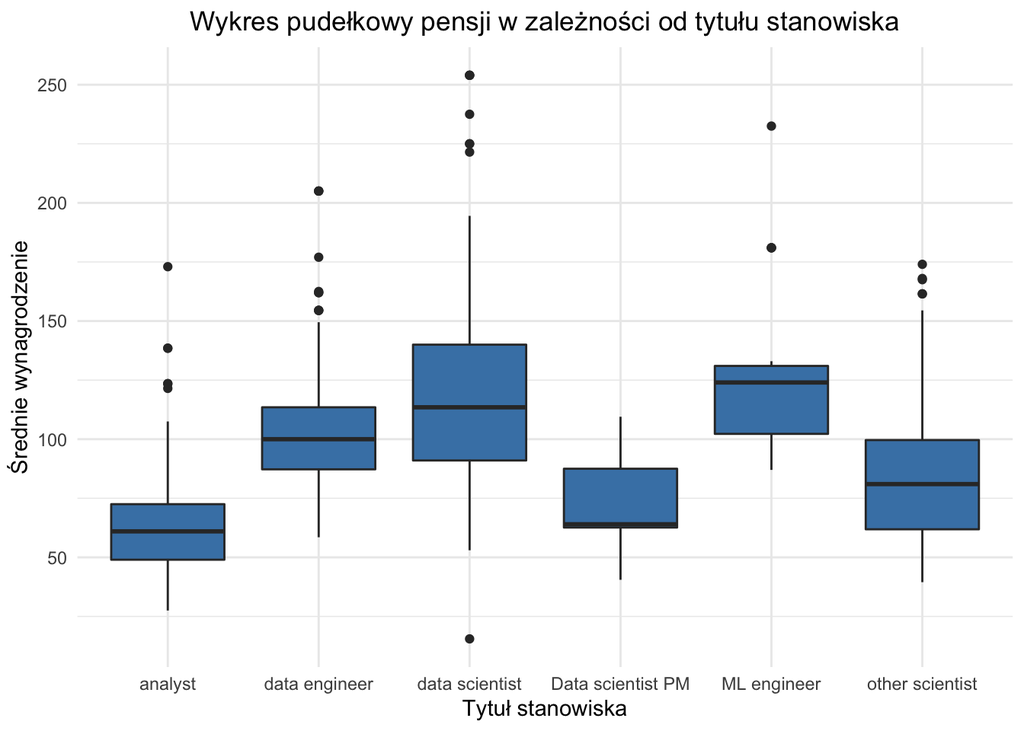

[output not shown]

```r
data <- data %>%
  filter(job_title_sim %in% unlist(c(top_count_title)))

plot4 <- ggplot(data, aes(x=job_title_sim, y=Avg.Salary.K.)) +
  geom_boxplot(fill="steelblue") +
  labs(title="Wykres pudełkowy pensji w zależności od tytułu stanowiska", x="Tytuł stanowiska", y="Średnie wynagrodzenie") +
  theme_minimal() +
  theme(plot.title = element_text(hjust = 0.5))
```